# R Notebook

## Breakout

```r
bike <- read.csv('https://raw.githubusercontent.com/IAA-Faculty/statistical_foundations/master/bike.csv')
```

You want to build a couple of different models and see which one is better. We will learn in later lectures how to do this with test datasets, but for right now we will only do this with training data. First, we need to split the data into training and test. Run the following code to get the training and test split:

```r
set.seed(123)
bike <- bike %>% mutate(id = row_number())
train <- bike %>% sample_frac(0.7)
test <- anti_join(bike, train, by = 'id')
```

What is the observation count in each dataset (train and test)? train - 12165 test - 5214

You can’t decide which variable is better to predict number of users (cnt), actual temperature (temp) or what the temperature feels like (atemp). You know they are highly correlated (correlation of approximately 0.99), but you feel that each might still provide some valuable information. Maybe the temperature provides (ever so slightly) different information than the feeling temperature. To keep them both in the model, build a ridge regression that has four variables: actual temperature (temp), feeling temperature (atemp), humidity (hum) and wind speed (windspeed). Use CV to find the penalty that minimizes the MSE. What is that lambda value?

7.388165

```r
train_reg <- train %>%
  dplyr::select(cnt, temp, atemp, hum, windspeed) %>%
  mutate_if(is.numeric, ~replace_na(., mean(., na.rm = TRUE)))

train_x <- model.matrix(cnt ~ ., data = train_reg)[, -1]
train_y <- train_reg$cnt
```

```r
test_reg <- test %>%
  dplyr::select(cnt, temp, atemp, hum, windspeed) %>%
  mutate_if(is.numeric, ~replace_na(., mean(., na.rm = TRUE)))

test_x <- model.matrix(cnt ~ ., data = test_reg)[, -1]
test_y <- test_reg$cnt
```

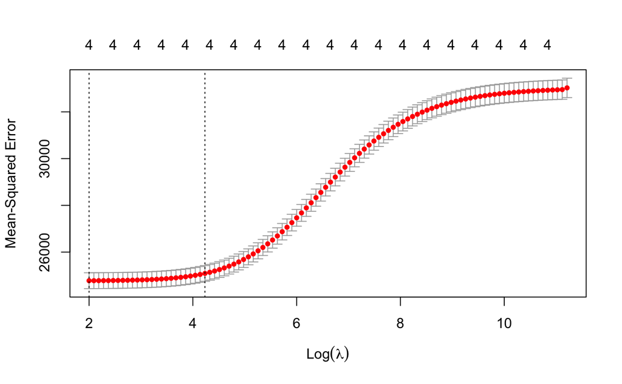

```r
library(glmnet)
bike_ridge <- glmnet(x = train_x, y = train_y, alpha = 0)


bike_ridge_cv <- cv.glmnet(x = train_x, y = train_y, alpha = 0)
plot(bike_ridge_cv)
```

```r
bike_ridge_cv$lambda.min
```

```
[1] 7.388165
```

Get predictions for this ridge regression on the test dataset. What are the first 5 predictions from the test dataset from this model? What are the respective actual values of cnt from this dataset?

Predictions:

```r
test$pred <- predict(bike_ridge, s = bike_ridge_cv$lambda.min, newx = test_x)
test$pred %>% head(5)
```

```
         s1
1  25.04585
2  92.24244
3  96.43314
4 117.79311
5  98.29221
```

Real:

```r
test$cnt %>% head(5)
```

```
[1]  3 56 34 39  6
```

A MLR with only feeling temperature, humidity, and windspeed had a test dataset MAPE of 478%. What was the MAPE from your ridge regression? From this comparison, which model would you choose?

The MLR has better MAPE so we should use that model.

```r
test %>%
  mutate(ridge_APE = 100*abs((cnt - pred)/cnt)) %>%
  dplyr::summarise(MAPE_ridge = mean(ridge_APE))
```

| MAPE_ridge |
| --- |
| 485.6342 |

## Lab

```r
library(AppliedPredictiveModeling)
data(FuelEconomy)
```

```r
cars2010_factor <- cars2010 %>% mutate(across(-c(FE, EngDispl), as.factor))
```

```r
set.seed(123)
cars2010_reg <- cars2010_factor %>%
  mutate_if(is.numeric, ~replace_na(., mean(., na.rm = TRUE)))

train_x <- model.matrix(FE ~ ., data = cars2010_reg)[, -1]
train_y <- cars2010_reg$FE
```

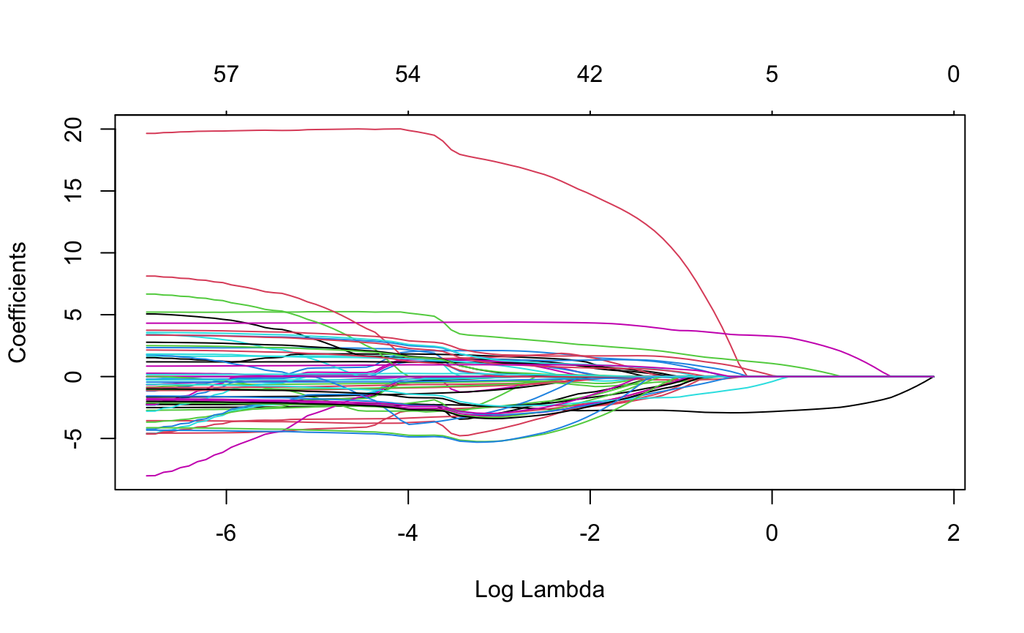

```r
cars_lasso <- glmnet(x = train_x, y = train_y, alpha = 1)
plot(cars_lasso, xvar = "lambda")
```

Perform a CV LASSO to optimize the lambda value. a. What is the value of lambda that minimizes the MSE? 0.003793359 b. What is the value of lambda one standard error above the minimum MSE value? 0.1428175 c. How many variables are left at the penalty value that is one standard error above the minimum MSE value (think of variables as a whole, not per category)? (HINT: Look at the coefficients from the model with coef function.) 11

```r
set.seed(123)
cars_lasso_cv <- cv.glmnet(x = train_x, y = train_y, alpha = 1)
cars_lasso_cv$lambda.min
```

```
[1] 0.003793359
```

```r
cars_lasso_cv$lambda.1se
```

```
[1] 0.1428175
```

```r
important <- abs(coef(cars_lasso, s = c(cars_lasso_cv$lambda.min, cars_lasso_cv$lambda.1se))[,1]) > 0 &
  abs(coef(cars_lasso, s = c(cars_lasso_cv$lambda.min, cars_lasso_cv$lambda.1se))[,2]) > 0

coef(cars_lasso, s = c(cars_lasso_cv$lambda.min, cars_lasso_cv$lambda.1se))[important,1]
```

```
                                    (Intercept)                                        EngDispl
                                    33.61951525                                     -2.24383228
                                        NumCyl3                                         NumCyl4
                                    19.90652487                                      5.22228457
                                       NumCyl10                                        NumCyl12
                                    -2.46171362                                     -3.64196606
                                 TransmissionA6                                  TransmissionA7
                                     0.02363191                                      3.96248158
                                TransmissionAM6                                 TransmissionAM7
                                    -4.45988119                                     -0.90544941
                                 TransmissionAV                                  TransmissionS4
                                    -0.01022461                                     -3.52513557
                                 TransmissionS5                                  TransmissionS6
                                    -0.62184828                                     -0.16394846
                AirAspirationMethodTurbocharged                                       NumGears4
                                    -1.08852412                                     -2.51161774
                                      NumGears5                                       NumGears8
                                    -2.18589330                                      1.49856505
                                   TransLockup1                         DriveDescFourWheelDrive
                                    -0.84751252                                     -0.43948457
                    DriveDescTwoWheelDriveFront                      DriveDescTwoWheelDriveRear
                                     4.32384902                                      1.18903229
                             IntakeValvePerCyl1                     CarlineClassDescCompactCars
                                     6.86002093                                      3.61628554
                      CarlineClassDescLargeCars                     CarlineClassDescMidsizeCars
                                     2.35685614                                      3.22138657
                CarlineClassDescMinicompactCars            CarlineClassDescSmallPickupTrucks2WD
                                     3.40540084                                     -1.99634585
           CarlineClassDescSmallPickupTrucks4WD CarlineClassDescSpecialPurposeVehicleminivan2WD
                                    -1.11050239                                     -2.20801291
    CarlineClassDescSpecialPurposeVehicleSUV2WD     CarlineClassDescSpecialPurposeVehicleSUV4WD
                                    -1.69389249                                     -0.76014580
        CarlineClassDescStandardPickupTrucks2WD         CarlineClassDescStandardPickupTrucks4WD
                                    -1.90411533                                     -2.12223854
                 CarlineClassDescSubcompactCars                  CarlineClassDescVansCargoTypes
                                     3.17727563                                     -4.24223961
              CarlineClassDescVansPassengerType                                 VarValveTiming1
                                    -4.43107920                                      0.19014885
                                  VarValveLift1
                                     0.87765867
```

```r
cars_lasso$dim
```

```
[1] 60 94
```

Obtain the variables from the LASSO regression at the penalty value that is one standard error above the minimum MSE value. The multiple linear regression with p-value selection (Lab 6) left the variables EngDispl, NumCyl, Transmission, AirAspirationMethod, NumGears, TransLockup, DriveDesc, IntakeValvePerCyl, CarlineClassDesc, and VarValveLift. a. What variables were left in your LASSO at the 1SE above minimum MSE penalty value?

```r
coef(cars_lasso, s = cars_lasso_cv$lambda.1se)[(abs(coef(cars_lasso, s = cars_lasso_cv$lambda.1se)[,1]) > 0), 1]
```

```
                                    (Intercept)                                        EngDispl
                                    41.97201941                                     -2.73948599
                                        NumCyl3                                         NumCyl4
                                    14.55383556                                      2.50949485
                                       NumCyl10                                        NumCyl12
                                    -1.22531175                                     -2.37684158
                                 TransmissionA5                                  TransmissionA6
                                    -0.33575071                                      0.04988998
                                 TransmissionA7                                 TransmissionAM6
                                     0.66123258                                     -2.31204847
                                TransmissionAM7                                  TransmissionAV
                                    -1.46858275                                      1.51331661
                                 TransmissionS4                                  TransmissionS5
                                    -2.05900220                                     -0.54993023
                                 TransmissionS6                 AirAspirationMethodTurbocharged
                                     0.13071106                                     -0.19366603
                                      NumGears4                                       NumGears5
                                    -0.80609711                                     -0.05477451
                                      NumGears8                                    TransLockup1
                                     0.95868618                                     -0.17061754
                        DriveDescFourWheelDrive                     DriveDescTwoWheelDriveFront
                                    -0.16556878                                      4.32999781
                     DriveDescTwoWheelDriveRear                              IntakeValvePerCyl1
                                     0.81178888                                      1.46993448
                    CarlineClassDescCompactCars                       CarlineClassDescLargeCars
                                     1.67173694                                      0.11077129
                    CarlineClassDescMidsizeCars                 CarlineClassDescMinicompactCars
                                     1.33520052                                      0.94921687
           CarlineClassDescSmallPickupTrucks2WD            CarlineClassDescSmallPickupTrucks4WD
                                    -2.13019020                                     -1.64295260
CarlineClassDescSpecialPurposeVehicleminivan2WD     CarlineClassDescSpecialPurposeVehicleSUV2WD
                                    -1.79442941                                     -2.22120288
    CarlineClassDescSpecialPurposeVehicleSUV4WD         CarlineClassDescStandardPickupTrucks2WD
                                    -2.00786252                                     -1.38620639
        CarlineClassDescStandardPickupTrucks4WD                  CarlineClassDescSubcompactCars
                                    -2.31855586                                      0.69212285
                 CarlineClassDescVansCargoTypes               CarlineClassDescVansPassengerType
                                    -3.36848371                                     -2.94993191
                                VarValveTiming1                                   VarValveLift1
                                     0.06957873                                      0.90563162
```

2. How does this compare against the variables from the multiple linear regression?